# chapter9 - Hypothesis testing & Anova in R

M Affouf

January 2, 2018

## Agenda

- Testing differences in mean between two groups
- QQ plots
- Tests for 2 x 2 tables, j x k tables
- Plotting confidence intervals

Let’s begin by loading the packages we’ll need to get started

```r
library(MASS)
library(plyr)
library(ggplot2)
```

## Exploring the birthwt data

The first thing we’ll do is apply the same pre-processing as on your homework to get the data into a nicer form.

```r
# Rename the columns to have more descriptive names
colnames(birthwt) <- c("birthwt.below.2500", "mother.age", "mother.weight",
    "race", "mother.smokes", "previous.prem.labor", "hypertension", "uterine.irr",
    "physician.visits", "birthwt.grams")

# Transform variables to factors with descriptive levels
birthwt <- transform(birthwt,
            race = as.factor(mapvalues(race, c(1, 2, 3),
                              c("white","black", "other"))),
            mother.smokes = as.factor(mapvalues(mother.smokes,
                              c(0,1), c("no", "yes"))),
            hypertension = as.factor(mapvalues(hypertension,
                              c(0,1), c("no", "yes"))),
            uterine.irr = as.factor(mapvalues(uterine.irr,
                              c(0,1), c("no", "yes")))
            )
```

Over the past two lectures we created various tables and graphics to help us better understand the data. Our focus for today is to run hypothesis tests to assess whether the trends we observed last time are statistically significant.

### Testing differences in means

One of the most common statistical tasks is to compare an outcome between two groups. The example here looks at comparing birth weight between smoking and non-smoking mothers.

To start, it always helps to plot things

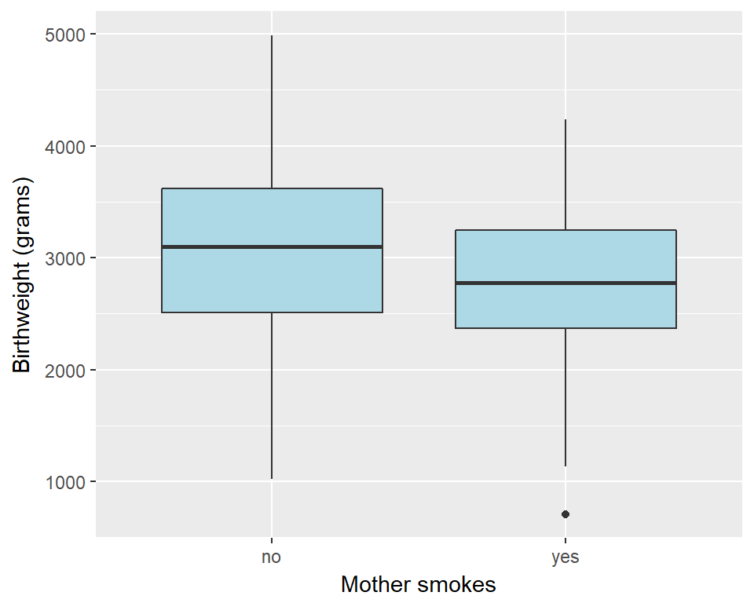

```r
# Create boxplot showing how birthwt.grams varies between
# smoking status
qplot(x = mother.smokes, y = birthwt.grams,
      geom = "boxplot", data = birthwt,
      xlab = "Mother smokes",
      ylab = "Birthweight (grams)",
      fill = I("lightblue"))
```

This plot suggests that smoking is associated with lower birth weight.

**How can we assess whether this difference is statistically significant?**

Let’s compute a summary table

```r
aggregate(birthwt.grams ~ mother.smokes,
          data = birthwt,
          FUN = function(x) {c(mean = mean(x), sd = sd(x))})
```

```
##   mother.smokes birthwt.grams.mean birthwt.grams.sd
## 1            no          3055.6957         752.6566
## 2           yes          2771.9189         659.6349
```

Note the way that the `FUN` argument was supplied in this `aggregate()` call. This function is never given a name. It’s an example of an **anonymous function**. In addition, the function returns a vector with *named elements*, giving the mean and standard deviation of the vector that’s passed to it.

The standard deviation is good to have, but to assess statistical significance we really want to have the standard error (which the standard deviation adjusted by the group size).

```r
aggregate(birthwt.grams ~ mother.smokes, data = birthwt,
          FUN = function(x) {c(mean = mean(x),
                               se = sd(x) / sqrt(length(x)))})
```

```
##   mother.smokes birthwt.grams.mean birthwt.grams.se
## 1            no         3055.69565         70.18559
## 2           yes         2771.91892         76.68100
```

#### t-test via t.test()

This difference is looking quite significant. To run a two-sample t-test, we can simple use the `t.test()` function.

```r
birthwt.t.test <- t.test(birthwt.grams ~ mother.smokes, data = birthwt)
birthwt.t.test
```

```
##
##  Welch Two Sample t-test
##
## data:  birthwt.grams by mother.smokes
## t = 2.7299, df = 170.1, p-value = 0.007003
## alternative hypothesis: true difference in means is not equal to 0
## 95 percent confidence interval:
##   78.57486 488.97860
## sample estimates:
##  mean in group no mean in group yes
##          3055.696          2771.919
```

We see from this output that the difference is highly significant. The `t.test()` function also outputs a confidence interval for us.

Notice that the function returns a lot of information, and we can access this information element by element

```r
names(birthwt.t.test)
```

```
## [1] "statistic"   "parameter"   "p.value"     "conf.int"    "estimate"
## [6] "null.value"  "alternative" "method"      "data.name"
```

```r
birthwt.t.test$p.value   # p-value
```

```
## [1] 0.007002548
```

```r
birthwt.t.test$estimate  # group means
```

```
##  mean in group no mean in group yes
##          3055.696          2771.919
```

```r
birthwt.t.test$conf.int  # confidence interval for difference
```

```
## [1]  78.57486 488.97860
## attr(,"conf.level")
## [1] 0.95
```

```r
attr(birthwt.t.test$conf.int, "conf.level")  # confidence level
```

```
## [1] 0.95
```

The ability to pull specific information from the output of the hypothesis test allows you to report your results using inline code chunks. That is, you don’t have to hardcode estimates, p-values, confidence intervals, etc.

```r
# Calculate difference in means between smoking and nonsmoking groups
birthwt.smoke.diff <- round(birthwt.t.test$estimate[1] - birthwt.t.test$estimate[2], 1)

# Confidence level as a %
conf.level <- attr(birthwt.t.test$conf.int, "conf.level") * 100
```

**Example**: Here’s what happens when we knit the following paragraph.

```r
Our study finds that birth weights are on average `r birthwt.smoke.diff`g higher in the non-smoking group compared to the smoking group (t-statistic `r round(birthwt.t.test$statistic,2)`, p=`r round(birthwt.t.test$p.value, 3)`, `r conf.level`% CI [`r round(birthwt.t.test$conf.int,1)`]g)
```

**Output**: Our study finds that birth weights are on average 283.8g higher in the non-smoking group compared to the smoking group (t-statistic 2.73, p=0.007, 95% CI [78.6, 489]g)

One other thing to know is that `t.test()` accepts input in multiple forms. I like using the formula form whenever it’s available, as I find it to be more easily interpretable. Here’s another way of specifying the same information.

```r
with(birthwt, t.test(x=birthwt.grams[mother.smokes=="no"],
                     y=birthwt.grams[mother.smokes=="yes"]))
```

```
##
##  Welch Two Sample t-test
##
## data:  birthwt.grams[mother.smokes == "no"] and birthwt.grams[mother.smokes == "yes"]
## t = 2.7299, df = 170.1, p-value = 0.007003
## alternative hypothesis: true difference in means is not equal to 0
## 95 percent confidence interval:
##   78.57486 488.97860
## sample estimates:
## mean of x mean of y
##  3055.696  2771.919
```

Specifying `x` and `y` arguments to the `t.test` function runs a t-test to check whether `x` and `y` have the same mean.

#### What is statistical significance testing doing?

Here’s a little simulation where we have two groups, a treatment groups and a control group. We’re going to simulate observations from both groups. We’ll run the simulation two ways.

- First simulation (Null case): the treatment has no effect
- Second simulation (Non-null case): the treatment on average increases outcome

```r
set.seed(12345)
# Function to generate data
generateSimulationData <- function(n1, n2, mean.shift = 0) {
  y <- rnorm(n1 + n2) + c(rep(0, n1), rep(mean.shift, n2))
  groups <- c(rep("control", n1), rep("treatment", n2))
  data.frame(y = y, groups = groups)
}
```

Let’s look at a single realization in the null setting.

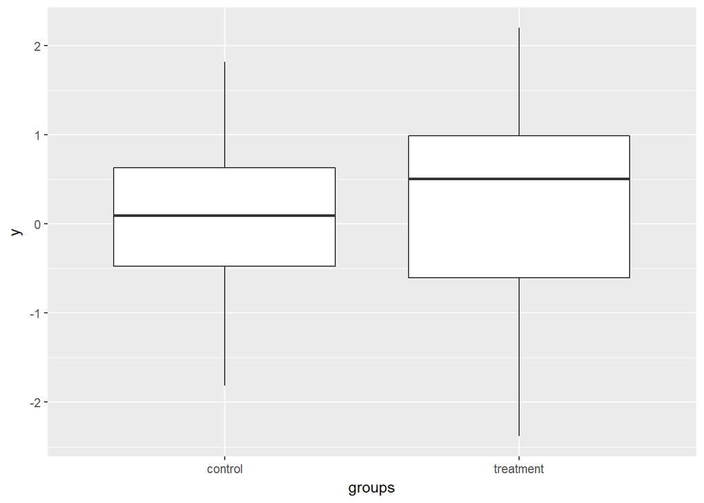

```r
n1 = 30
n2 = 40
# Observation, null case
obs.data <- generateSimulationData(n1 = n1, n2 = n2)

# Box plots
qplot(x = groups, y = y, data = obs.data, geom = "boxplot")
```

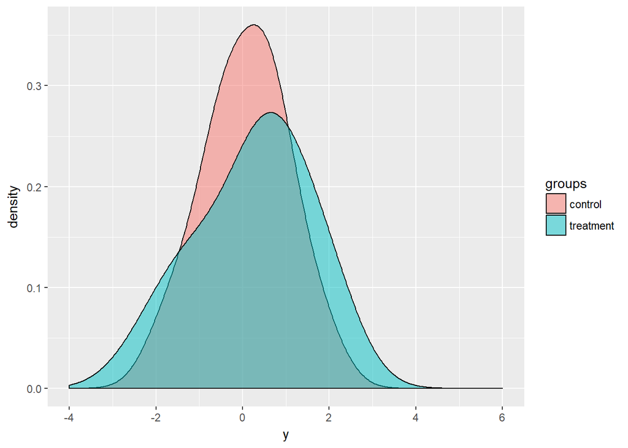

```r
# Density plots
qplot(fill = groups, x = y, data = obs.data, geom = "density",
      alpha = I(0.5),
      adjust = 1.5,
      xlim = c(-4, 6))
```

```r
# t-test
t.test(y ~ groups, data = obs.data)
```

```
##
##  Welch Two Sample t-test
##
## data:  y by groups
## t = -0.61095, df = 67.998, p-value = 0.5433
## alternative hypothesis: true difference in means is not equal to 0
## 95 percent confidence interval:
##  -0.6856053  0.3641889
## sample estimates:
##   mean in group control mean in group treatment
##              0.07880701              0.23951518
```

And here’s what happens in a random realization in the non-null setting.

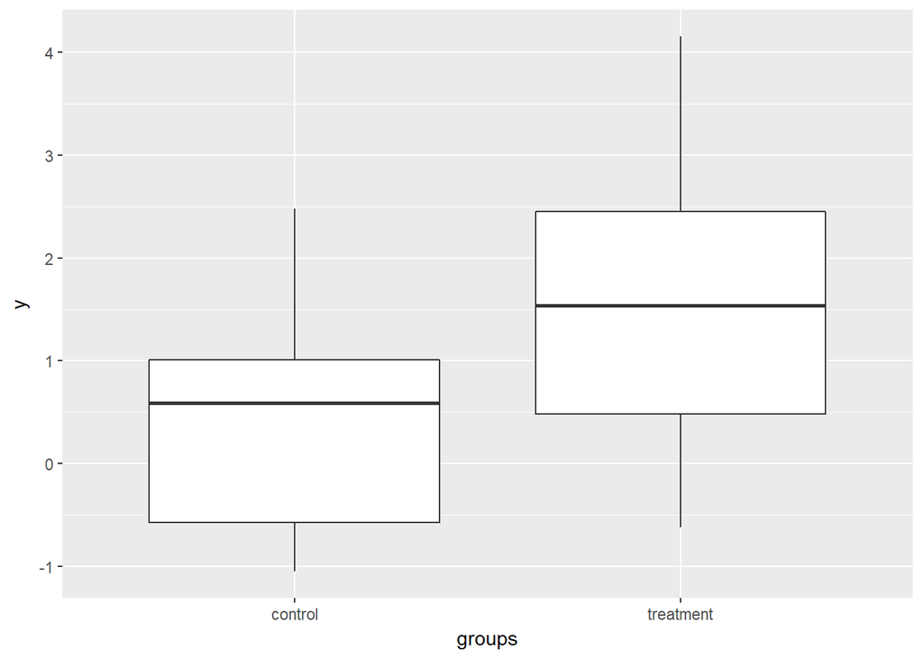

```r
# Non-null case, very strong treatment effect
# Observation, null case
obs.data <- generateSimulationData(n1 = n1, n2 = n2, mean.shift = 1.5)

# Box plots
qplot(x = groups, y = y, data = obs.data, geom = "boxplot")
```

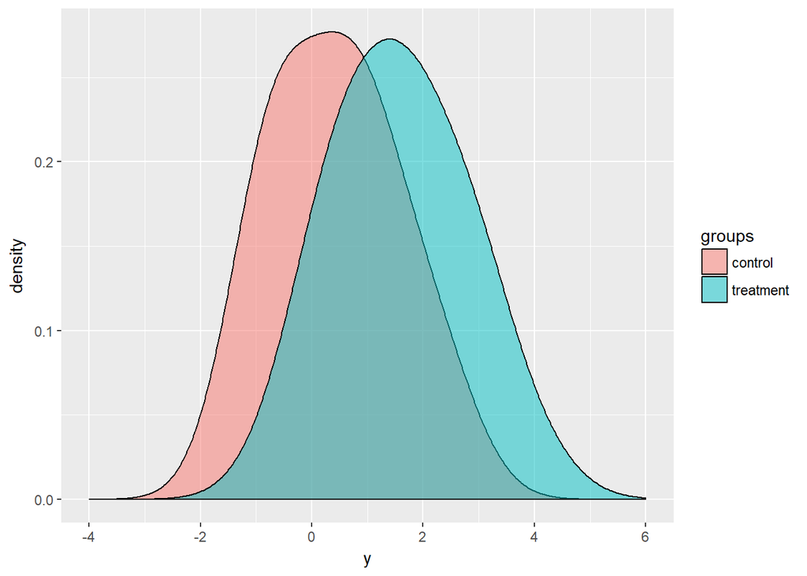

```r
# Density plots
qplot(fill = groups, x = y, data = obs.data, geom = "density",
      alpha = I(0.5),
      adjust = 1.5,
      xlim = c(-4, 6))
```

```r
# t-test
t.test(y ~ groups, data = obs.data)
```

```
##
##  Welch Two Sample t-test
##
## data:  y by groups
## t = -4.3081, df = 64.785, p-value = 5.708e-05
## alternative hypothesis: true difference in means is not equal to 0
## 95 percent confidence interval:
##  -1.6911828 -0.6197985
## sample estimates:
##   mean in group control mean in group treatment
##               0.4191634               1.5746541
```

More interestingly, let’s see what happens if we repeat our simulation 10000 times and look at the p-values. We’ll use a moderate effect of 0.5 instead of the really strong effect of 1.5 in this simulation.

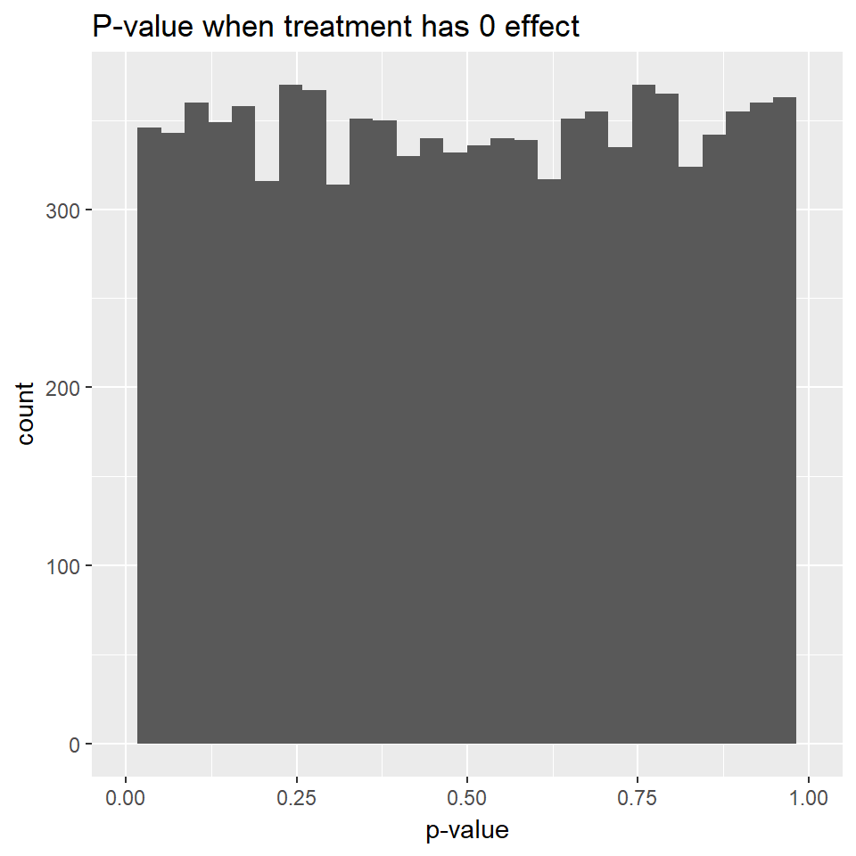

```r
NUM_ITER <- 10000
pvals <- matrix(0, nrow = NUM_ITER, ncol = 2)
for(i in 1:NUM_ITER) {
  # Generate data
  obs.null <- generateSimulationData(n1 = n1, n2 = n2)
  obs.alt <- generateSimulationData(n1 = n1, n2 = n2, mean.shift = 0.5)

  # Record p-values
  pvals[i, 1] <- t.test(y ~ groups, data = obs.null)$p.value
  pvals[i, 2] <- t.test(y ~ groups, data = obs.alt)$p.value
}

pvals <- as.data.frame(pvals)
colnames(pvals) <- c("null", "nonnull")

# Plotting routine
qplot(x = null, data = pvals, xlab = "p-value",
      xlim = c(0, 1),
      main = "P-value when treatment has 0 effect")
```

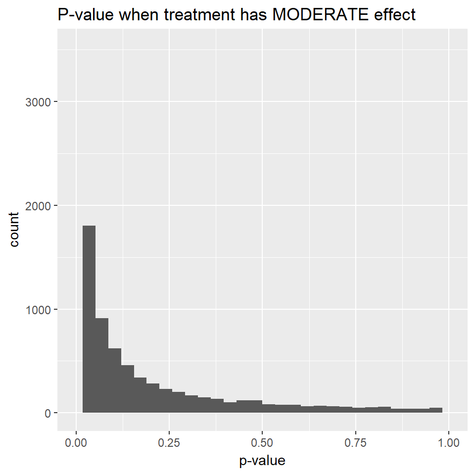

```r
qplot(x = nonnull, data = pvals, xlab = "p-value",
      xlim = c(0, 1),
      main = "P-value when treatment has MODERATE effect")
```

Let’s show both histograms on the same plot.

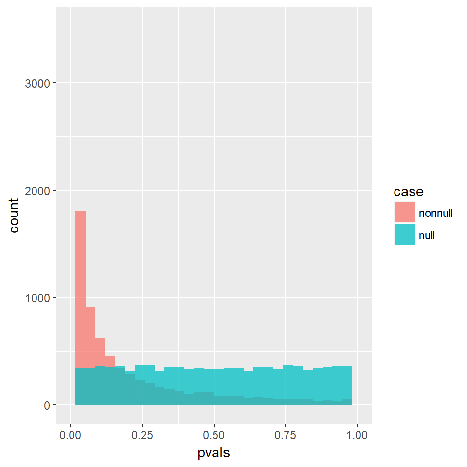

```r
# Let's start by reshaping the data
# This approach isn't the best one, but it works well for this simple case
pvals.df <- data.frame(pvals = c(pvals$null, pvals$nonnull),
                       case = c(rep("null", NUM_ITER), rep("nonnull", NUM_ITER)))

# Plot
ggplot(data = pvals.df, aes(x = pvals, fill = case)) +
  geom_histogram(alpha=0.75, position="identity") +
  xlim(0,1)
```

#### What if sample is small and data are non-Gaussian?

In your statistics classes you’ve been taught to approach the t-test with caution. If your data is highly skewed, you would need a very large sample size for the t-statistic to actually be t-distributed.

When it doubt, you can run a non-parametric test. Here’s how we run a Mann-Whitney U test (aka Wilcoxon rank-sum test) using the `wilcox.test()` function.

```r
# Formula specification
birthwt.wilcox.test <- wilcox.test(birthwt.grams ~ mother.smokes, data=birthwt, conf.int=TRUE)
birthwt.wilcox.test
```

```
##
##  Wilcoxon rank sum test with continuity correction
##
## data:  birthwt.grams by mother.smokes
## W = 5249.5, p-value = 0.006768
## alternative hypothesis: true location shift is not equal to 0
## 95 percent confidence interval:
##   85.00004 512.00005
## sample estimates:
## difference in location
##               306.1846
```

```r
# x,y specification
with(birthwt, wilcox.test(x=birthwt.grams[mother.smokes=="no"],
                     y=birthwt.grams[mother.smokes=="yes"]))
```

```
##
##  Wilcoxon rank sum test with continuity correction
##
## data:  birthwt.grams[mother.smokes == "no"] and birthwt.grams[mother.smokes == "yes"]
## W = 5249.5, p-value = 0.006768
## alternative hypothesis: true location shift is not equal to 0
```

In general, hypothesis tests in R return an object of class `htest` which has similar attributes to what we saw in the t-test.

```r
class(birthwt.wilcox.test)
```

```
## [1] "htest"
```

Here’s a summary of the attributes:

| name | description |
| --- | --- |
| statistic | the value of the test statistic with a name describing it. |
| parameter | the parameter(s) for the exact distribution of the test statistic. |
| p.value | the p-value for the test. |
| null.value | the location parameter mu. |
| alternative | a character string describing the alternative hypothesis |
| method | the type of test applied. |
| data.name | a character string giving the names of the data. |
| conf.int | a confidence interval for the location parameter. (Only present if argument conf.int = TRUE.) |
| estimate | an estimate of the location parameter. (Only present if argument conf.int = TRUE.) |

### Is the data normal?

I would recommend using a non-parametric test when the data appears highly non-normal and the sample size is small. If you really want to stick to t-testing, it’s good to know how to diagnose non-normality.

#### qq-plot

The simplest thing to look at is a normal qq plot of the data. This is obtained using the `qqnorm()` function.

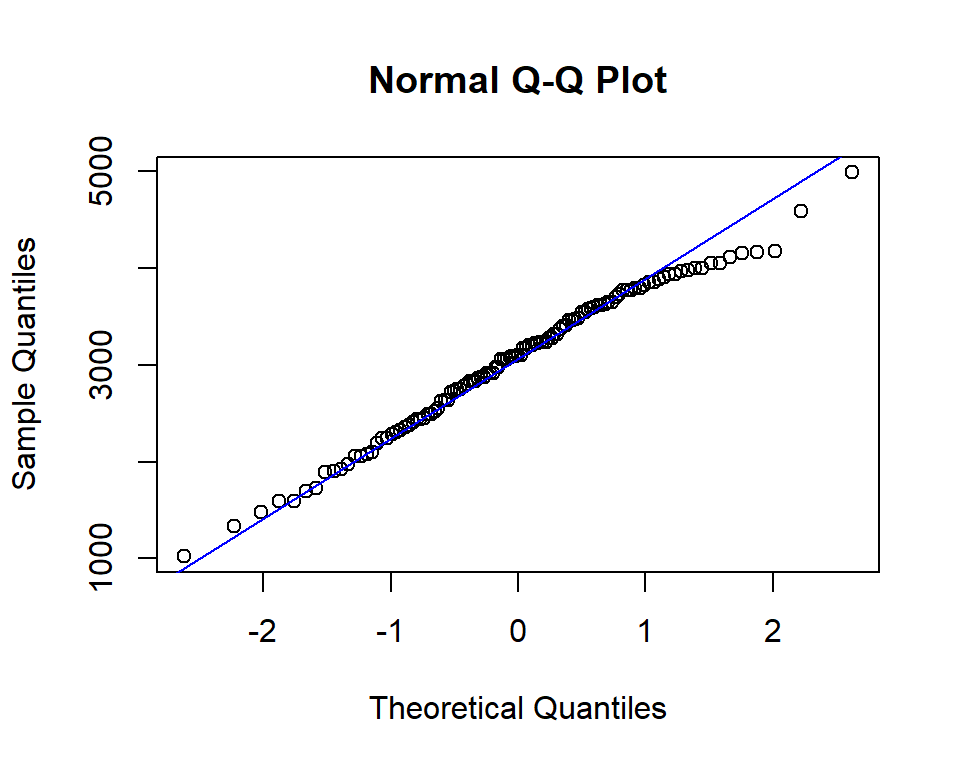

```r
# qq plot
with(birthwt, qqnorm(birthwt.grams[mother.smokes=="no"]))
# add reference line
with(birthwt, qqline(birthwt.grams[mother.smokes=="no"], col = "blue"))
```

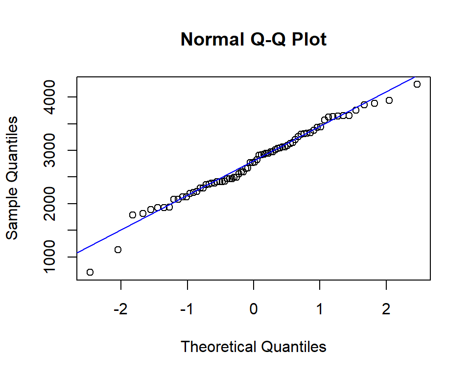

```r
# qq plot
with(birthwt, qqnorm(birthwt.grams[mother.smokes=="yes"]))
# add reference line
with(birthwt, qqline(birthwt.grams[mother.smokes=="yes"], col = "blue"))
```

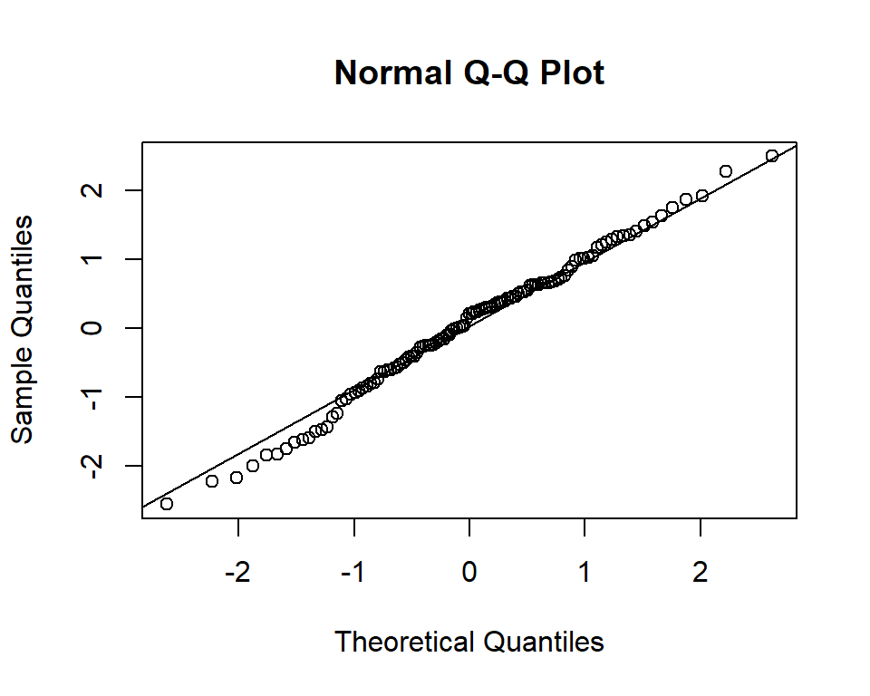

```r
# qq plot
x <- rnorm(115); qqnorm(x); qqline(x)
```

If the data are exactly normal, you expect the points to lie on a straight line. The data we have here are pretty close to lying on a line.

Here’s what we would see if the data were right-skewed

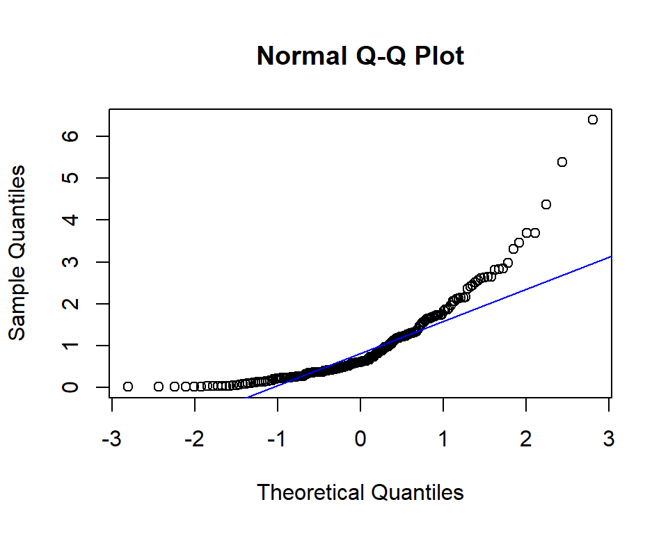

```r
set.seed(12345)
fake.data <- rexp(200)
qqnorm(fake.data)
qqline(fake.data, col = "blue") # add line
```

If you construct a qqplot and it looks like this, you should be carefully, particularly if your sample size is small.

### Tests for 2x2 tables

Here’s an example of a 2 x 2 table that we might want to run a test on. This one looks at low birthweight broken down by mother’s smoking status. You can think of it as another approach to the t-test problem, this time looking at indicators of low birth weight instead of the actual weights.

First, let’s build our table using the `table()` function (we did this back in Lecture 5)

```r
weight.smoke.tbl <- with(birthwt, table(birthwt.below.2500, mother.smokes))
weight.smoke.tbl
```

```
##                   mother.smokes
## birthwt.below.2500 no yes
##                  0 86  44
##                  1 29  30
```

We also previously calculated the odds ratio for this table, finding that it was approximately 2. This indicated that the odds of low birthweight double when the mother smokes.

To test for significance, we just need to pass our 2 x 2 table into the appropriate function. Here’s the result of using fisher’s exact test by calling `fisher.test`

```r
birthwt.fisher.test <- fisher.test(weight.smoke.tbl)
birthwt.fisher.test
```

```
##
##  Fisher's Exact Test for Count Data
##
## data:  weight.smoke.tbl
## p-value = 0.03618
## alternative hypothesis: true odds ratio is not equal to 1
## 95 percent confidence interval:
##  1.028780 3.964904
## sample estimates:
## odds ratio
##   2.014137
```

```r
attributes(birthwt.fisher.test)
```

```
## $names
## [1] "p.value"     "conf.int"    "estimate"    "null.value"  "alternative"
## [6] "method"      "data.name"
##
## $class
## [1] "htest"
```

As when using the t-test, we find that there is a significant association between smoking an low birth weight.

You can also use the chi-squared test via the `chisq.test` function. This is the test that you may be more familiar with from your statistics class.

```r
chisq.test(weight.smoke.tbl)
```

```
##
##  Pearson's Chi-squared test with Yates' continuity correction
##
## data:  weight.smoke.tbl
## X-squared = 4.2359, df = 1, p-value = 0.03958
```

You get essentially the same answer by running the chi-squared test, but the output isn’t as useful. In particular, you’re not getting an estimate or confidence interval for the odds ratio. This is why I prefer `fisher.exact()` for testing 2 x 2 tables.

#### Tests for j x k tables

Here’s a small data set on party affiliation broken down by gender.

```r
# Manually enter the data
politics <- as.table(rbind(c(762, 327, 468), c(484, 239, 477)))
dimnames(politics) <- list(gender = c("F", "M"),
                    party = c("Democrat","Independent", "Republican"))

politics # display the data
```

```
##       party
## gender Democrat Independent Republican
##      F      762         327        468
##      M      484         239        477
```

We may be interested in asking whether men and women have different party affiliations.

The answer will be easier to guess at if we convert the rows to show proportions instead of counts. Here’s one way of doing this.

```r
politics.prop <- apply(politics, 1, FUN = function(x) {x / sum(x)})
politics.prop
```

```
##              gender
## party                 F         M
##   Democrat    0.4894027 0.4033333
##   Independent 0.2100193 0.1991667
##   Republican  0.3005780 0.3975000
```

```r
colSums(politics.prop) # Check that columns sum to 1
```

```
## F M
## 1 1
```

```r
politics.prop <- t(politics.prop) # Transpose the table

# Fix dimnames
dimnames(politics.prop) <- list(gender = c("F", "M"),
                    party = c("Democrat","Independent", "Republican"))

# Output
politics.prop
```

```
##       party
## gender  Democrat Independent Republican
##      F 0.4894027   0.2100193   0.300578
##      M 0.4033333   0.1991667   0.397500
```

By looking at the table we see that Female are more likely to be Democrats and less likely to be Republicans.

We still want to know if this difference is significant. To assess this we can use the chi-squared test (on the counts table, not the proportions table!).

```r
chisq.test(politics)
```

```
##
##  Pearson's Chi-squared test
##
## data:  politics
## X-squared = 30.07, df = 2, p-value = 2.954e-07
```

There isn’t really a good one-number summary for general $j$ x $k$ tables the way there is for 2 x 2 tables. One thing that we may want to do at this stage is to ignore the Independent category and just look at the 2 x 2 table showing the counts for the Democrat and Republican categories.

```r
politics.dem.rep <- politics[,c(1,3)]
politics.dem.rep
```

```
##       party
## gender Democrat Republican
##      F      762        468
##      M      484        477
```

```r
# Run Fisher's exact test
fisher.test(politics.dem.rep)
```

```
##
##  Fisher's Exact Test for Count Data
##
## data:  politics.dem.rep
## p-value = 6.806e-08
## alternative hypothesis: true odds ratio is not equal to 1
## 95 percent confidence interval:
##  1.347341 1.910944
## sample estimates:
## odds ratio
##   1.604345
```

We see that women have significantly higher odds of being Democrat compared to men.

### Plotting the table values with confidence

It may be useful to represent the data graphically. Here’s one way of doing so with the `ggplot2` package. Note that we plot the **proportions** not the counts.

**1.** Convert the table into something ggplot2 can process by using `melt()` from the `reshape` package.

```r
library(reshape)
politics.prop
```

```
##       party
## gender  Democrat Independent Republican
##      F 0.4894027   0.2100193   0.300578
##      M 0.4033333   0.1991667   0.397500
```

```r
politics.melt <- melt(politics.prop, id=c("gender","party"))
politics.melt
```

```
##   gender       party     value
## 1      F    Democrat 0.4894027
## 2      M    Democrat 0.4033333
## 3      F Independent 0.2100193
## 4      M Independent 0.1991667
## 5      F  Republican 0.3005780
## 6      M  Republican 0.3975000
```

**2.** Create a ggplot2 object, and plot with `geom_barplot()`

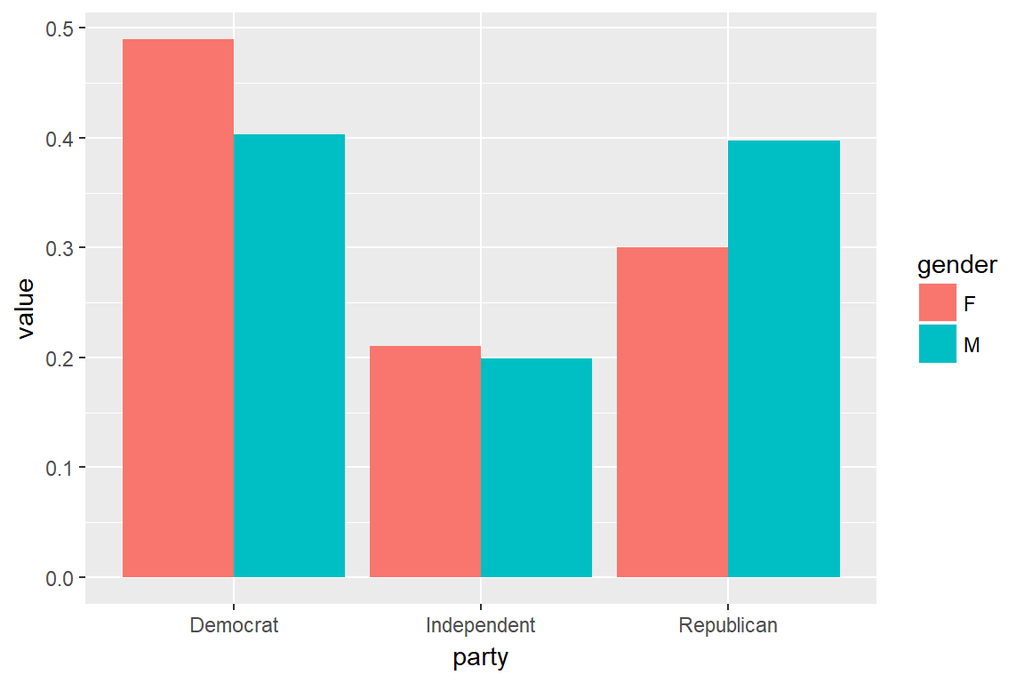

```r
ggplot(politics.melt, aes(x=party, y=value, fill=gender)) + geom_bar(position="dodge", stat="identity")
```

This figure is a nice alternative to displaying a table. One thing we might want to add is a way of gauging the statistical significance of the differences in height. We’ll do so by adding error bars.

#### Adding error bars to bar plots

Remember, ggplot wants everything you plot to be sitting nicely in a data frame. Here’s some code that will calculate the relevant values and do the plotting.

**1.** Get the data into a form that’s easy to work with.

```r
# Form into a long data frame
politics.count.melt <- melt(politics, id=c("gender", "party"))
# print
politics.count.melt
```

```
##   gender       party value
## 1      F    Democrat   762
## 2      M    Democrat   484
## 3      F Independent   327
## 4      M Independent   239
## 5      F  Republican   468
## 6      M  Republican   477
```

```r
# Add a column of marginal counts
politics.count.melt <- transform(politics.count.melt, totals = rowSums(politics)[gender])
# print
politics.count.melt
```

```
##   gender       party value totals
## 1      F    Democrat   762   1557
## 2      M    Democrat   484   1200
## 3      F Independent   327   1557
## 4      M Independent   239   1200
## 5      F  Republican   468   1557
## 6      M  Republican   477   1200
```

**2.** Calculate confidence intervals.

To calculate confidence intervals for the proportions, we can use `prop.test` or `binom.test`. Essentially you call these functions the numerator and denominator for the proportion.

We’ll do this in a for loop.

```r
# define list of prop, and lower and upper endpoints
conf.ints <- list(prop = NULL, lower = NULL, upper = NULL)
for(i in 1:nrow(politics.count.melt)) {
  numerator <- politics.count.melt$value[i]
  denominator <- politics.count.melt$totals[i]
  prop.test.out <- prop.test(numerator, denominator)

  # Add estimate of proportion to list
  conf.ints[["prop"]][i] <- prop.test.out$estimate
  # Grab confidence interval
  interval <- prop.test.out$conf.int
  # Add estimate and endpoints to conf.ints list
  conf.ints[["lower"]][i] <- interval[1]
  conf.ints[["upper"]][i] <- interval[2]
}
conf.ints
```

```
## $prop
## [1] 0.4894027 0.4033333 0.2100193 0.1991667 0.3005780 0.3975000
##
## $lower
## [1] 0.4643094 0.3755178 0.1902041 0.1771484 0.2780035 0.3697701
##
## $upper
## [1] 0.5145489 0.4317750 0.2312844 0.2231402 0.3241480 0.4258939
```

**3.** Combine the confidence intervals into the data frame

```r
politics.toplot <- cbind(politics.count.melt, conf.ints)
politics.toplot
```

```
##   gender       party value totals      prop     lower     upper
## 1      F    Democrat   762   1557 0.4894027 0.4643094 0.5145489
## 2      M    Democrat   484   1200 0.4033333 0.3755178 0.4317750
## 3      F Independent   327   1557 0.2100193 0.1902041 0.2312844
## 4      M Independent   239   1200 0.1991667 0.1771484 0.2231402
## 5      F  Republican   468   1557 0.3005780 0.2780035 0.3241480
## 6      M  Republican   477   1200 0.3975000 0.3697701 0.4258939
```

**4.** Use `ggplot()`, `geom_bar()` and `geom_errorbar()` to construct the plots

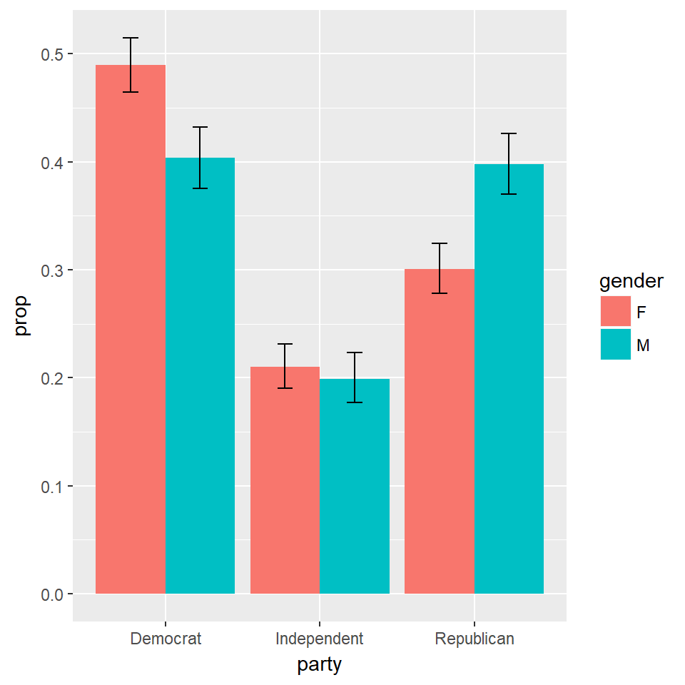

```r
ggplot(politics.toplot, aes(x=party, y=prop, fill=gender)) +
  geom_bar(position="dodge", stat="identity") +
  geom_errorbar(aes(ymin=lower, ymax=upper),
                width=.2,                    # Width of the error bars
                position=position_dodge(0.9))
```

### ANOVA

You can think of ANOVA (analysis of variance) as a more general version of the t-test, or a special case of linear regression in which all covariates are factors.

Let’s go back to our favourite birthwt data set from the MASS library.

#### One-way ANOVA example

**Question: Is there a significant association between race and birthweight?**

```r
aggregate(birthwt.grams ~ race, data = birthwt, FUN = mean)
```

```
##    race birthwt.grams
## 1 black      2719.692
## 2 other      2805.284
## 3 white      3102.719
```

It looks like there’s some association, but we don’t yet know if it’s statistically significant. Note that if we had just two racial categories in our data, we could run a t-test. Since we have more than 2, we need to run a 1-way analysis of variance (ANOVA).

**Terminology**: a $k$-way ANOVA is used to assess whether the mean of an outcome variable is constant across all combinations of $k$ factors. The most common examples are 1-way ANOVA (looking at a single factor), and 2-way ANOVA (looking at two factors).

We’ll use the `aov()` function. For convenience, `aov()` allows you to specify a formula.

```r
summary(aov(birthwt.grams ~ race, data = birthwt))
```

```
##              Df   Sum Sq Mean Sq F value  Pr(>F)
## race          2  5015725 2507863   4.913 0.00834 **
## Residuals   186 94953931  510505
## ---
## Signif. codes:  0 '***' 0.001 '**' 0.01 '*' 0.05 '.' 0.1 ' ' 1
```

The p-value is significant at the 0.05 level, so the data suggests that there is an association between birthweight and race. In other words, average birthweight varies across the three racial groups considered in the data.